# Préparation CCF E5.2 : Vidéosurveillance

Ce système sera utilisé dans le cadre de l’épreuve de CCF E5.2.

## Présentation

Le système est constitué :

- de 3 caméras IP Wanscam JW0008 ;
- d’un réseau cablé Ethernet 100BASET ;
- d’un switch Ethernet ;
- d’un poste de surveillance ;
- d’un point d’accès Wifi (en option) ;
- d’un serveur de stockage FTP ;
- d’un routeur (en option) pour un accès distant ;
- de manuels, logiciels de tests et supervision.

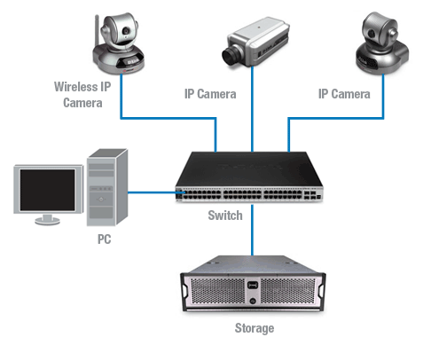

Le diagramme des cas d’utilisation du système est le suivant :

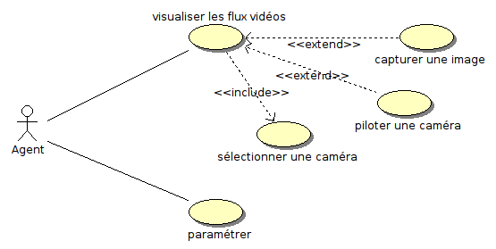

## Contraintes d’environnement

| Ressource | Version |
| --- | --- |
| OS | GNU Linux (Ubuntu 12.04.5 LTS) |
| EDI | Qt Creator 2.4.1 |
| Compilateur | GNU g++/gcc version 4.6.3 |
| Débugueur | GNU gdb 7.4 |
| Fabrication | QMake 2.01a et GNU make 3.81 |
| API GUI | Qt 4.8.1 |

## Manuel d’installation

Exécuter le programme d’installation setup et suivre les différentes étapes :

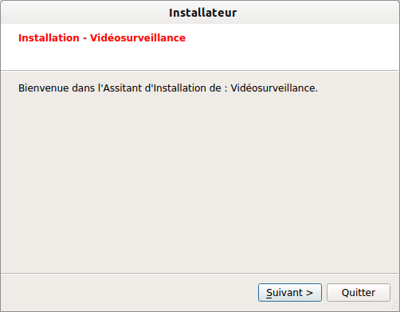

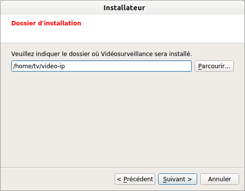

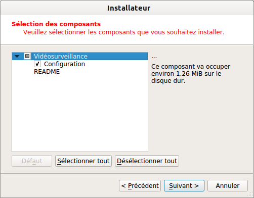

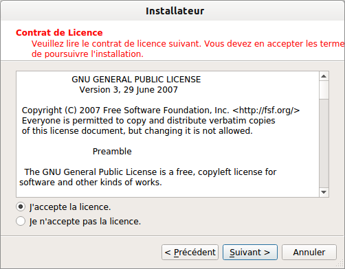

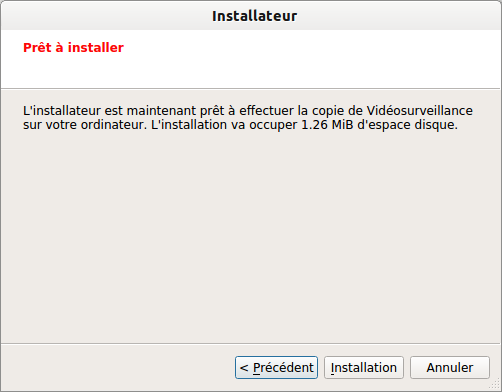

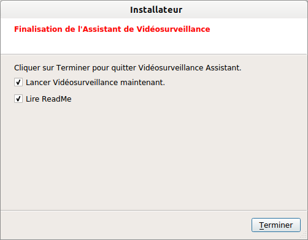

L’application gère ses paramètres de configuration à partir d’un fichier `videosurveillance.ini` :

```
; dans cette version : 4 caméras max.

[camera1]
adresse="192.168.52.14"
port=99
user=admin
pwd=
script=mobile.htm

[camera2]
adresse="192.168.52.25"
port=81
user=admin
pwd=
script=monitor.htm

[camera3]
adresse="192.168.52.216"
port=99
user=admine
pwd=
script=serverpush.htm
```

La caméra Wanscam fournit 5 accès possibles pour la valeur de la clé `script` :

- `index.htm` : page d’accueil
- `admin.htm` : page d’administration
- `mobile.htm` : page pour Mobile
- `monitor.htm` : page pour navigateur Internet Explorer (ActiveX)
- `serverpush.htm` : page pour navigateurs FireFox, Chrome …

## Serveur FTP

Les caméras sauvegardent périodiquement les images vers un serveur FTP (vsFTPd). Un pare-feu est installé en configuration `close-config`. L’administration du serveur se fait via **ssh**.

```
# Example config file /etc/vsftpd.conf
listen=YES
listen_ipv6=NO
anonymous_enable=NO
local_enable=YES
write_enable=YES
xferlog_enable=YES
connect_from_port_20=YES
chroot_local_user=YES
allow_writeable_chroot=YES
local_root=/var/ftp
secure_chroot_dir=/var/run/vsftpd/empty
pam_service_name=vsftpd
rsa_cert_file=/etc/ssl/certs/ssl-cert-snakeoil.pem
rsa_private_key_file=/etc/ssl/private/ssl-cert-snakeoil.key
ssl_enable=NO
```

Une tâche *cron* archive toutes les images sauvegardées d’une semaine chaque dimanche à 23h59.

## Manuel d’utilisation

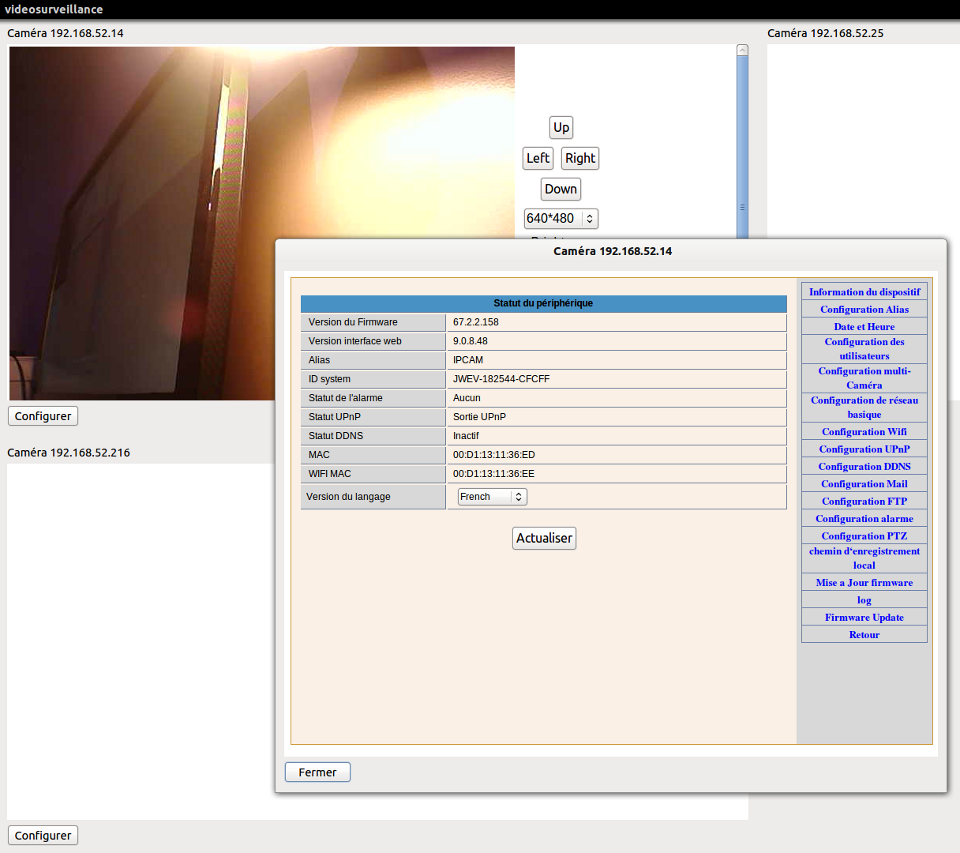

```
L'application consigne des messages, évènements, avertissements et erreurs dans un journal videosurveillance.log.
```

## Glossaire

- Télésurveillance : La télésurveillance est un système technique structuré en réseau permettant de surveiller à distance des lieux (publics ou privés), des machines ou des individus. Ce système s’est généralisé à Londres durant les années 1980, suite aux attentats menés par l’IRA. Et c’est également en Angleterre, bien avant qu’il ne devienne une réalité, que sont nées les premières inquiétudes quant à son utilisation à des fins de contrôle social. Dès 1949, en effet, l’écrivain George Orwell décrivait dans son roman d’anticipation 1984 un univers entièrement sous la coupe d’un personnage appelé Big Brother (en réalité une incarnation de l’État totalitaire) capable d’identifier les faits et gestes de toute une population grâce à un immense parc de caméras disséminées partout dans la ville.
- Vidéosurveillance : La vidéosurveillance ou vidéo-protection, parfois désignée par le sigle anglais CCTV (closed-circuit television), est un système de caméras et de transmission d’images, disposé dans un espace public ou privé pour le surveiller à distance ; il s’agit donc d’un type de télésurveillance. Les images obtenues avec ce système, peuvent être traitées automatiquement et/ou visionnées puis archivées ou détruites. La surveillance a pour but de contrôler les conditions de respect de la sécurité, de la sûreté ou de l’exécution d’une procédure particulière.
- Caméra IP : Une caméra IP ou caméra réseau est une caméra de surveillance utilisant le Protocole Internet pour transmettre des images et des signaux de commande via une liaison Fast Ethernet. Certaines caméras IP sont reliées à un enregistreur vidéo numérique (DVR) ou un enregistreur vidéo en réseau (NVR) pour former un système de surveillance vidéo.
- Power over Ethernet (PoE) : Power over Ethernet (alimentation électrique par câble Ethernet) est définie par la norme IEEE 802.3af, appartenant au standard IEEE 802.3 (Ethernet). Elle permet de faire passer une tension de 48 V (jusqu’à 13 W de puissance électrique, voire plus) en plus des données à 100 Mbit/s ou 1 Gbit/s. Cette technologie alloue deux paires (ou plus) sur les quatre paires que contient un câble UTP ou STP afin d’alimenter certains appareils d’un réseau Ethernet tels que des téléphones IP, des disques durs réseaux, des imprimantes, des caméras IP ou des points d’accès Wi-Fi.
- NAS : Un serveur de stockage en réseau, également appelé stockage en réseau NAS, boîtier de stockage en réseau ou plus simplement NAS (Network Attached Storage), est un serveur de fichiers autonome, relié à un réseau dont la principale fonction est le stockage de données en un volume centralisé pour des clients réseau hétérogènes. Le composant informatique principal de ce type de serveur est le disque dur.
- Image numérique : désigne toute image (dessin, icône, photographie …) acquise, créée, traitée et stockée sous forme binaire. Un format d’image est donc une représentation informatique de l’image, associée à des informations sur la façon dont l’image est codée et fournissant éventuellement des indications sur la manière de la décoder et de la manipuler (métadonnées). On distingue essentiellement deux types d’images : les images matricielles (ou images bitmap) et les images vectorielles.
- Image matricielle : Une image matricielle, ou « carte de points » (*bitmap*), est une image constituée d’une matrice de points colorés. C’est-à-dire, constituée d’un tableau, d’une grille, où chaque case possède une couleur qui lui est propre et est considérée comme un point. Il s’agit donc d’une juxtaposition de points de couleurs formant, dans leur ensemble, une image. Les inconvénients de ce type d’image sont la perte de qualité lorsqu’on désire l’agrandir indéfiniment et le fort encombrement pour stocker l’ensemble des pixels (que l’on peut compenser en utilisant une compression). L’avantage est le traitement rapide pour afficher ce type d’image. Les formats matriciels les plus utilisés sont : JPEG, GIF, PNG et TIFF.
- Image vectorielle : Le principe est de représenter les données de l’image par des formules géométriques qui vont pouvoir être décrites d’un point de vue mathématique. Cela signifie qu’au lieu de mémoriser une mosaïque de points élémentaires, on stocke la succession d’opérations conduisant au tracé. Par exemple, un dessin peut être mémorisé par l’ordinateur comme « une droite tracée entre les points (x1, y1) et (x2, y2) », puis « un cercle tracé de centre (x3, y3) et de rayon 30 de couleur rouge ». L’avantage de ce type d’image est la possibilité de l’agrandir indéfiniment sans perdre la qualité initiale, ainsi qu’un faible encombrement. L’inconvénient est le fort traitement “mathématique” associé à ce type d’image. Exemple de format vectoriel : SVG.
- Définition : La définition d’une image est définie par le nombre de points la composant. En image numérique, cela correspond au nombre de pixels qui composent l’image en hauteur (axe vertical) et en largeur (axe horizontal) : 200 pixels par 450 pixels par exemple, abrégé en « 200 × 450 ».
- Résolution : La résolution d’une image est définie par un nombre de pixels par unité de longueur de la structure à numériser (classiquement en ppp). Ce paramètre est défini lors de la numérisation (passage de l’image sous forme binaire), et dépend principalement des caractéristiques du matériel utilisé lors de la numérisation. Plus le nombre de pixels par unité de longueur de la structure à numériser est élevé, plus la quantité d’information qui décrit cette structure est importante et plus la résolution est élevée. La résolution d’une image numérique définit le degré de détail de l’image. Ainsi, plus la résolution est élevée, meilleure est la restitution.
- MJPEG : Le Motion JPEG ou M-JPEG est un codec vidéo qui compresse les images une à une en JPEG. Le débit binaire d’un flux MJPEG se situe généralement entre celui de formats non compressés (comme RVB de compression 1:1) et celui des formats MPEG (de l’ordre de 1:100). Des débits de l’ordre de 29 Mbit/s sont courants pour des vidéos de très bonne qualité, mais conduisent en comparaison à d’autres formats à des tailles de fichier très importantes. H.264, ou MPEG-4 AVC (*Advanced Video Coding*) est une autre norme de codage vidéo.
- JPEG : JPEG est l’acronyme de Joint Photographic Experts Group. C’est une norme qui définit le format d’enregistrement et l’algorithme de décodage pour une représentation numérique compressée d’une image fixe. Les extensions de nom de fichiers les plus communes pour les fichiers employant la compression JPEG sont .jpg et .jpeg.

## Activités

- Matériels : Caméra IP Wanscam JW008
- Réseau : Ethernet, TCP/IP, FTP
- Fichiers : LOG, INI, HTML, Javascript
- Serveurs : [Serveur Ubuntu](http://tvaira.free.fr/bts-sn/admin/tp-installation-serveur.pdf), [Serveur FTP](http://tvaira.free.fr/bts-sn/admin/tp-installation-ftp.pdf), [Parefeu](http://tvaira.free.fr/bts-sn/admin/tp-installation-parefeu.pdf), [Utilisateurs](http://tvaira.free.fr/bts-sn/admin/tp-installation-utilisateurs.pdf), [Processus](http://tvaira.free.fr/bts-sn/admin/tp-installation-processus.pdf), PHP

Retour au sommaire